# Assurance for an Inteirm Look - DTE Example

These are the parameters we have chosen, they are the same as the example given in both papers

```r
P_S <- 0.9
P_DTE <- 0.7
delay_time_SHELF <- SHELF::fitdist(c(3, 4, 5), probs = c(0.25, 0.5, 0.75), lower = 0, upper = 10)
post_delay_HR_SHELF <- SHELF::fitdist(c(0.55, 0.6, 0.7), probs = c(0.25, 0.5, 0.75), lower = 0, upper = 1.5)
post_delay_HR_dist <- "gamma"
delay_time_dist <- "gamma"
n_c <- 300
n_t <- 300
lambda_c <- 0.08
rec_method <- "power"
rec_period <- 12
rec_power <- 1
cens_method <- "Events"
cens_events <- 450
```

Here, we control the different information fractions we will look at, and the number of simulations we will conduct

```r
IF <- seq(0.1, 1, by=0.1)
NSims <- 1e1
```

Here we simulate `NSims` trials according to the parameters set out in the chunk above. For each trial, we conduct interim analyses at different information fractions, again, according to the pre-specified information fractions above.

NOTE: we are only considering performing ONE interim analysis here.

Here we calculate the assurance (if we had let all the trials go to the end)

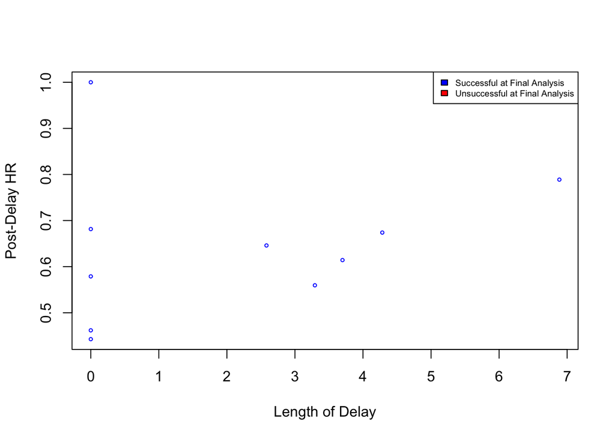

```
## [1] 1
```

We now pretend we had conducted an interim analysis for each of the trials. As such, there are four different outcomes that each indivuval trial can have:

- Stop for Efficacy
- Stop for Futility
- Successful at the final analysis (implicitly implied that we continued at the IA)
- Unsuccessful at the final analysis (implicitly implied that we continued at the IA)

Here, we plot the TRUE, UNDERLYING parameters used to sample the different trials. We then colour the points by the FOUR different outcomes each trial could have had

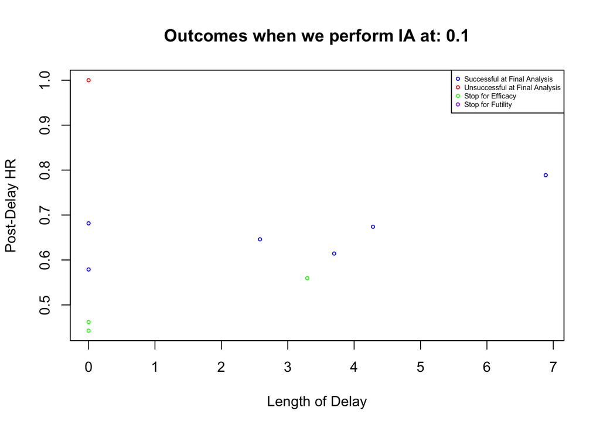

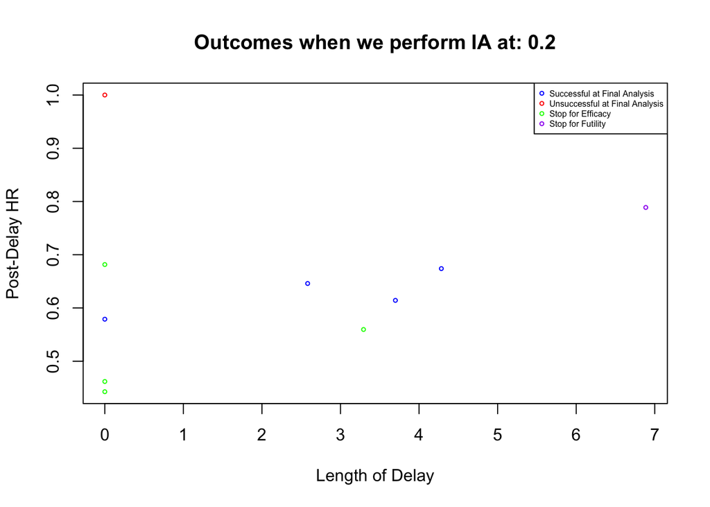

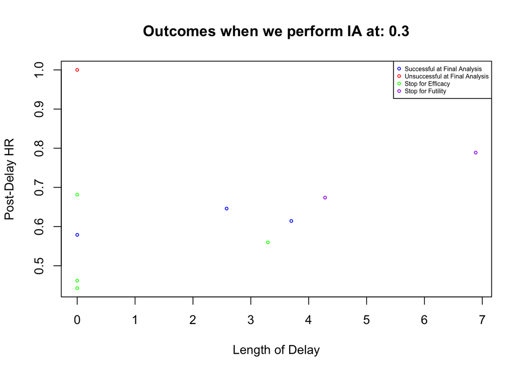

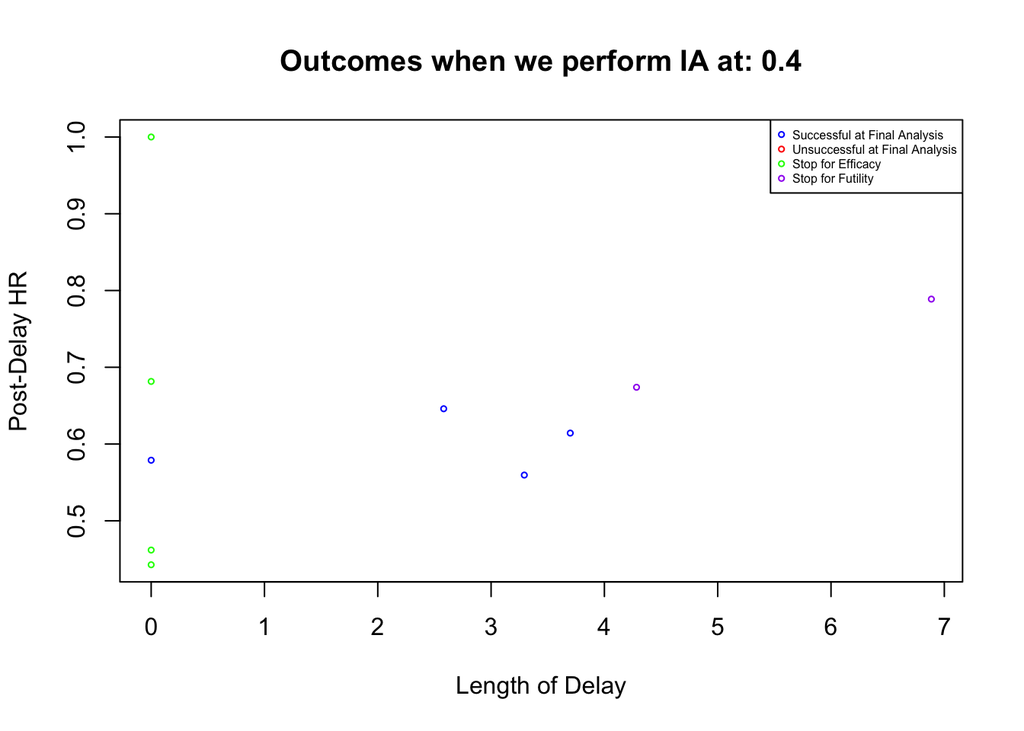

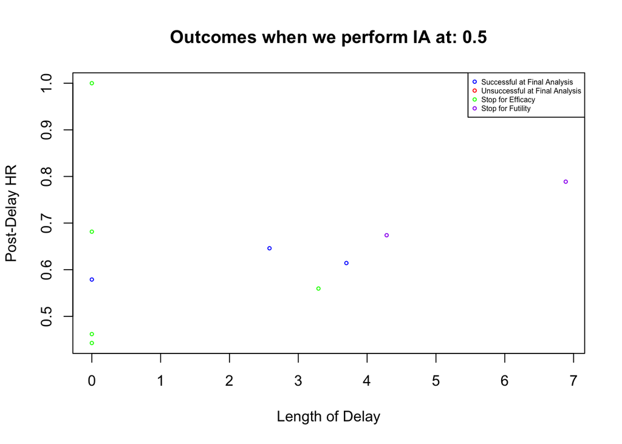

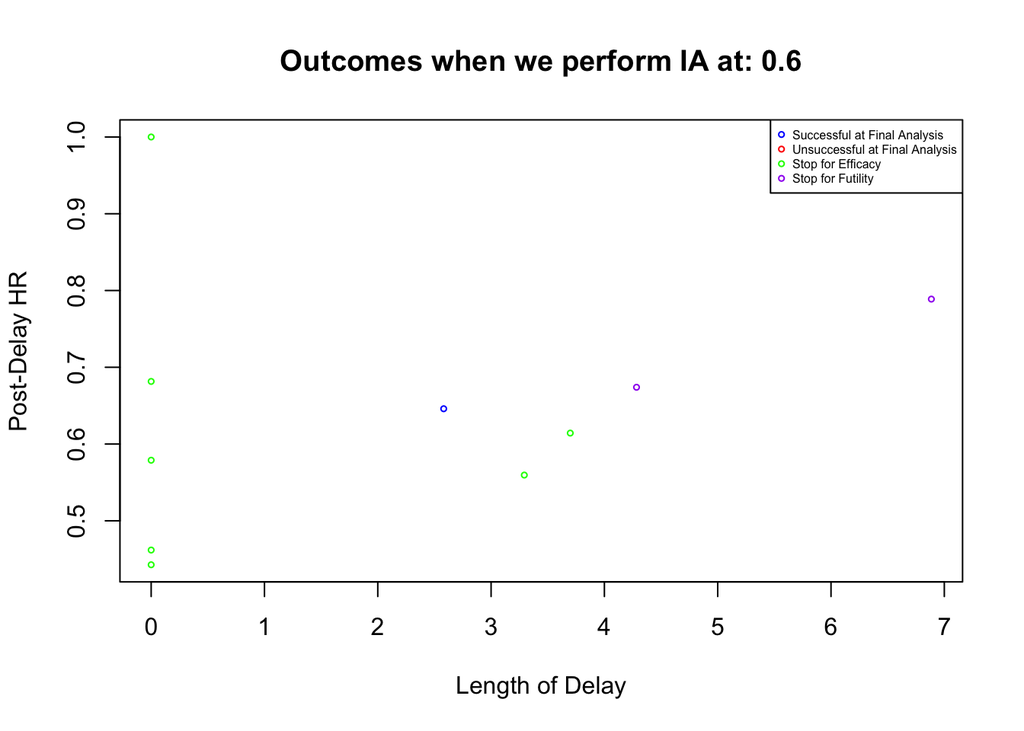

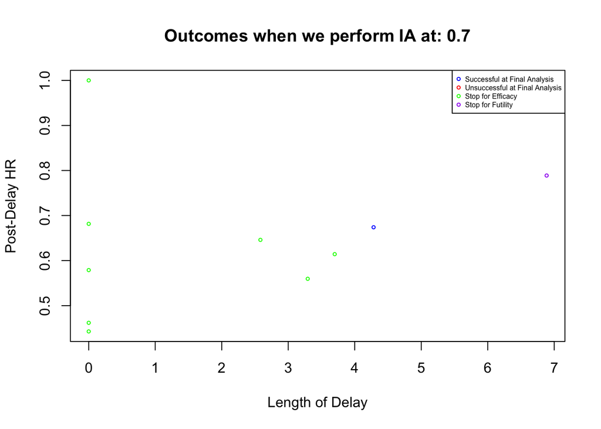

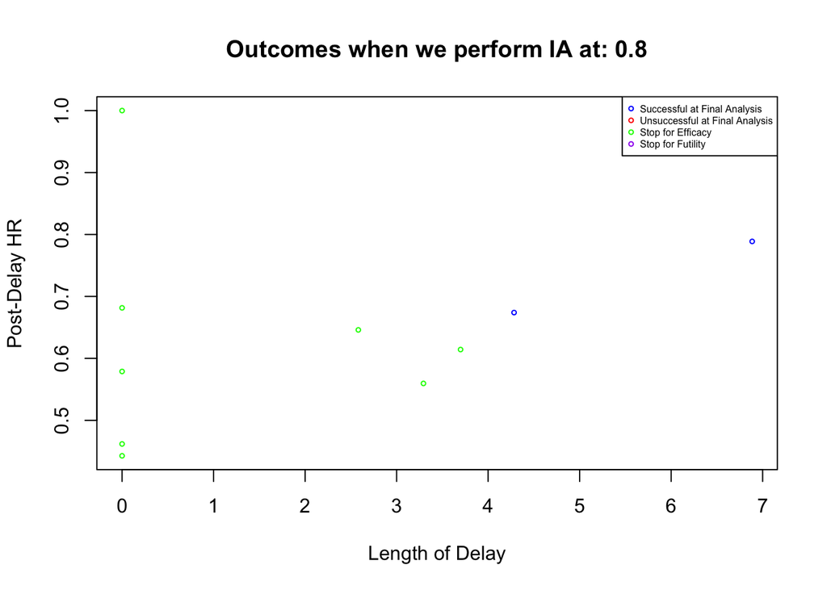

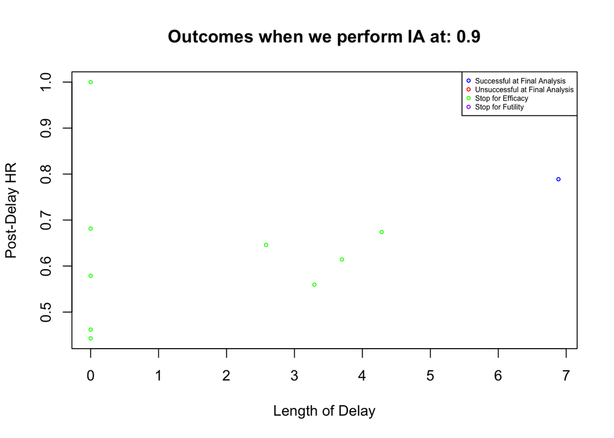

We also show this in table format

```
##                                0.1 0.2 0.3 0.4 0.5 0.6 0.7 0.8 0.9 1
## Successful at Final Analysis   0.6 0.4 0.3 0.4 0.3 0.1 0.1 0.2 0.1 1
## Unsuccessful at Final Analysis 0.1 0.1 0.1 0.0 0.0 0.0 0.0 0.0 0.0 0
## Stop for Efficacy              0.3 0.4 0.4 0.4 0.5 0.7 0.8 0.8 0.9 0
## Stop for Futility              0.0 0.1 0.2 0.2 0.2 0.2 0.1 0.0 0.0 0
```

and a stacked barchart (so we can see the trends as we change information fractions),

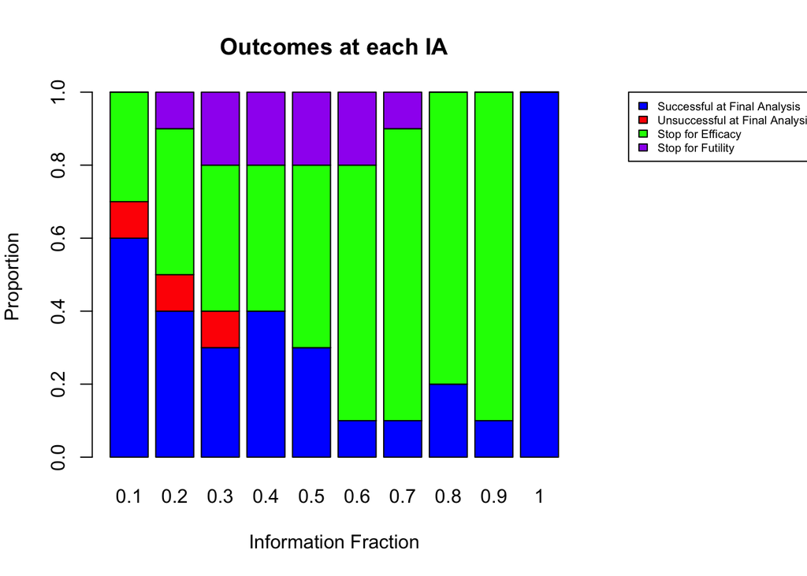

So alongside the FOUR outcomes we could have had. We also can work out whether this decision was correct or not. As we have access to, what would have happened if we did not conduct an interim analysis. So when we have the proportion of trials that stopped for futility, this is further broken down into:

*Correctly stopped for futility (this trial would have gone on to be unsuccessful)* Incorrectly stopped for futility (this trial would have gone on to be successful)

And the same for efficacy:

*Correctly stopped for efficacy (this trial would have gone on to be successful)* Incorrectly stopped for efficacy (this trial would have gone on to be unsuccessful)

so we now have SIX different (potential) outcomes for our trial:

*Correctly stopped for futility* Incorrectly stopped for futility *Correctly stopped for efficacy* Incorrectly stopped for efficacy *Successful at the final analysis* Unsuccessful at the final analysis

We see the same scatter plots, of the TRUE, UNDERLYING parameters, this time coloured by the different outcomes

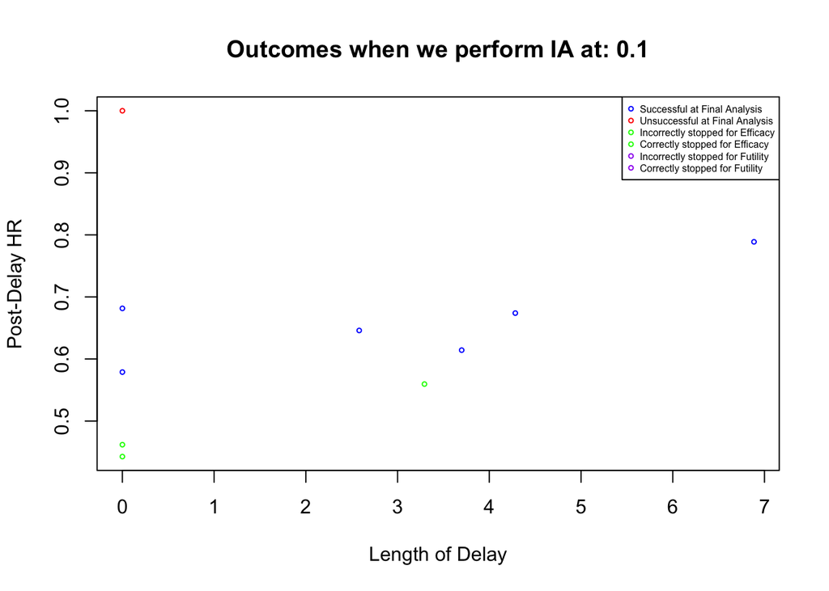

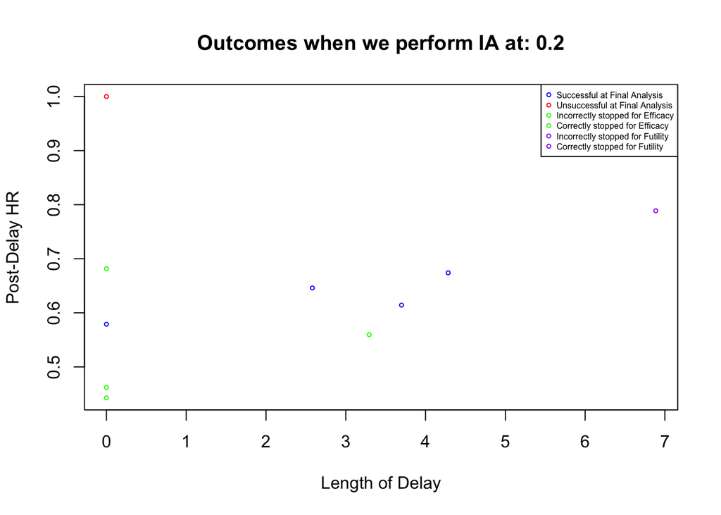

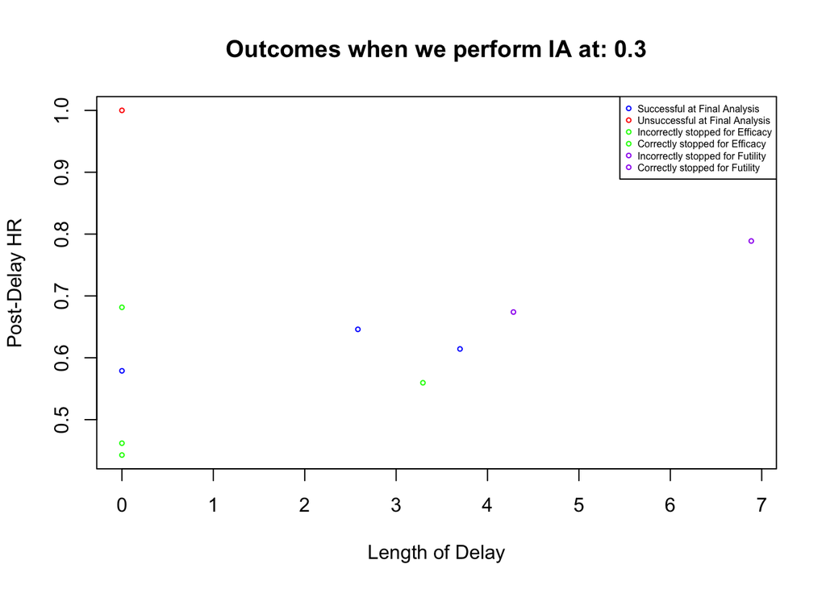

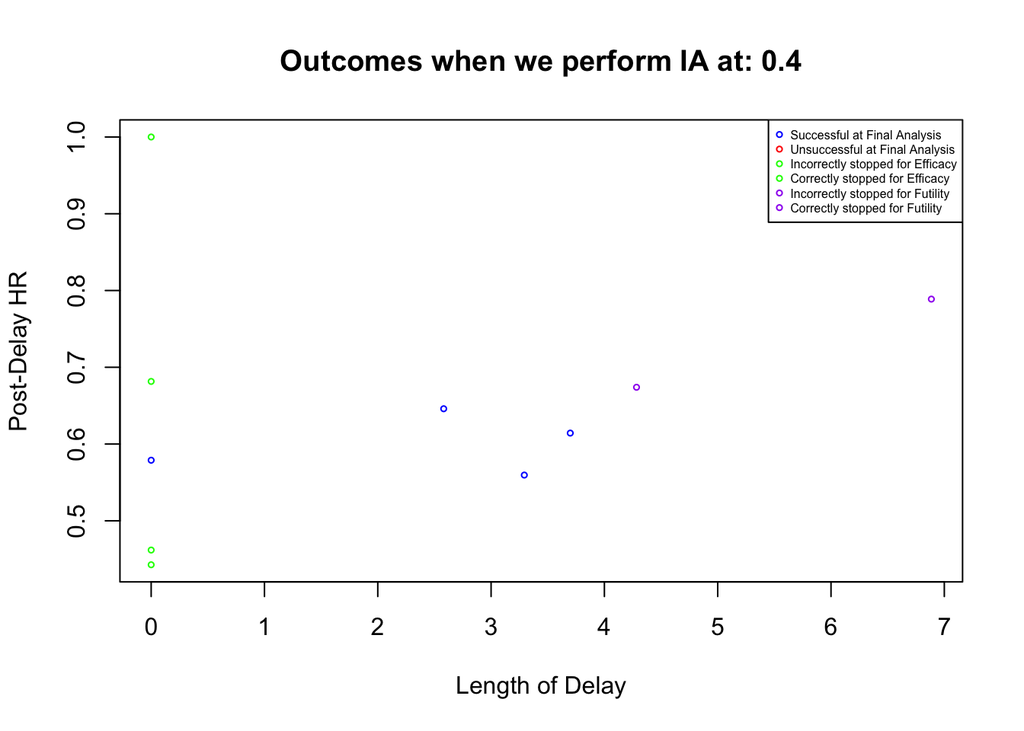

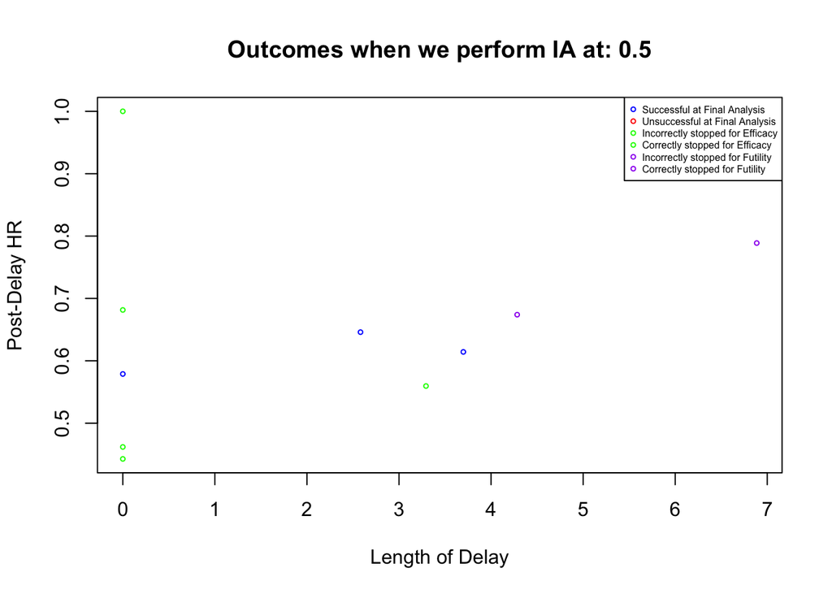

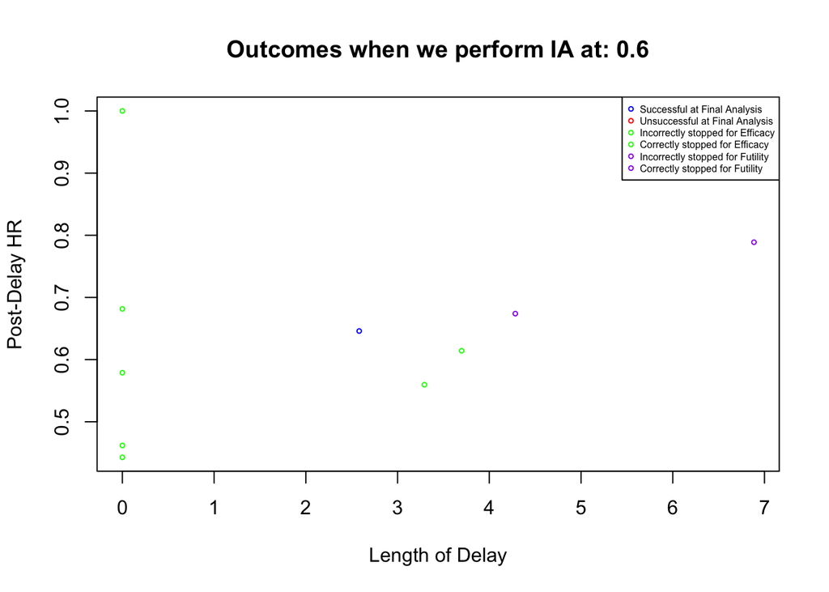

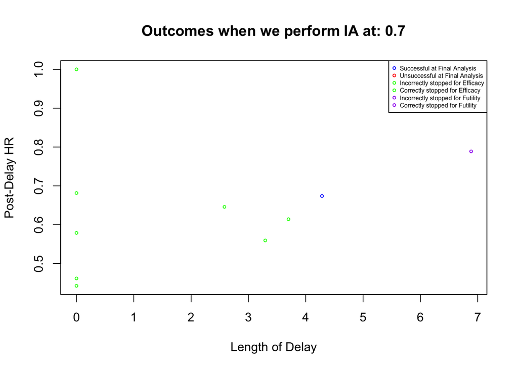

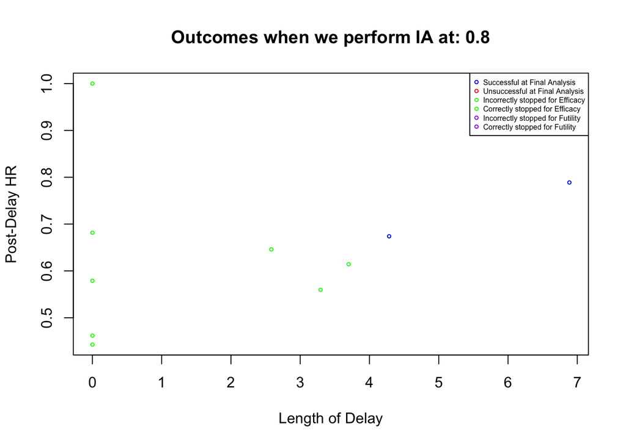

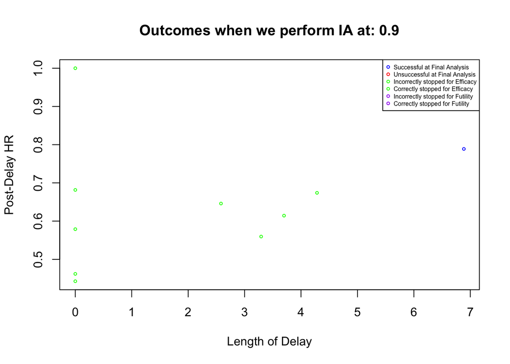

Same table, but with the extra outcomes

```
##                                  0.1 0.2 0.3 0.4 0.5 0.6 0.7 0.8 0.9 1
## Successful at Final Analysis     0.6 0.4 0.3 0.4 0.3 0.1 0.1 0.2 0.1 1
## Unsuccessful at Final Analysis   0.1 0.1 0.1 0.0 0.0 0.0 0.0 0.0 0.0 0
## Incorrectly stopped for Efficacy 0.0 0.0 0.0 0.0 0.0 0.0 0.0 0.0 0.0 0
## Correctly stopped for Efficacy   0.3 0.4 0.4 0.4 0.5 0.7 0.8 0.8 0.9 0
## Incorrectly stopped for Futility 0.0 0.1 0.2 0.2 0.2 0.2 0.1 0.0 0.0 0
## Correctly stopped for Futility   0.0 0.0 0.0 0.0 0.0 0.0 0.0 0.0 0.0 0
```

and finally, the stacked barchart again. Same colours as the other barchart, but now we can see the probability of making the (in)correct decision.

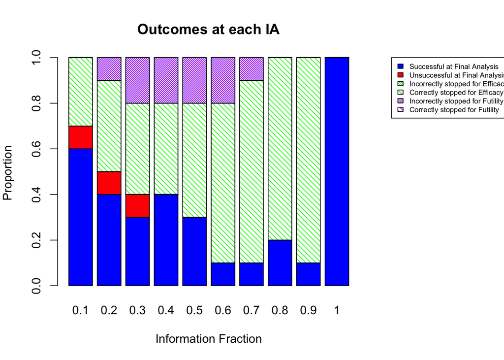